# Final Project

#### Question 3: What is the impact of working from home on productivity change? - Sector & Working from Home

```
## [1] "Segmentation Analysis: Number of Individuals with Productivity Change by Sector and Work From Home"
## # A tibble: 8 × 3
##   Sector     Work_From_Home Count
##   <chr>               <dbl> <int>
## 1 Education               0   249
## 2 Education               1  1013
## 3 Healthcare              0   247
## 4 Healthcare              1  1003
## 5 IT                      0   259
## 6 IT                      1  1026
## 7 Retail                  0   232
## 8 Retail                  1   993
## [1] "Segmentation Analysis: Number of Individuals with Productivity Change by Sector and Work From Home"
## # A tibble: 8 × 3
##   Sector     Work_From_Home Count
##   <chr>               <dbl> <int>
## 1 Education               0   249
## 2 Education               1  1013
## 3 Healthcare              0   247
## 4 Healthcare              1  1003
## 5 IT                      0   259
## 6 IT                      1  1026
## 7 Retail                  0   232
## 8 Retail                  1   993
```

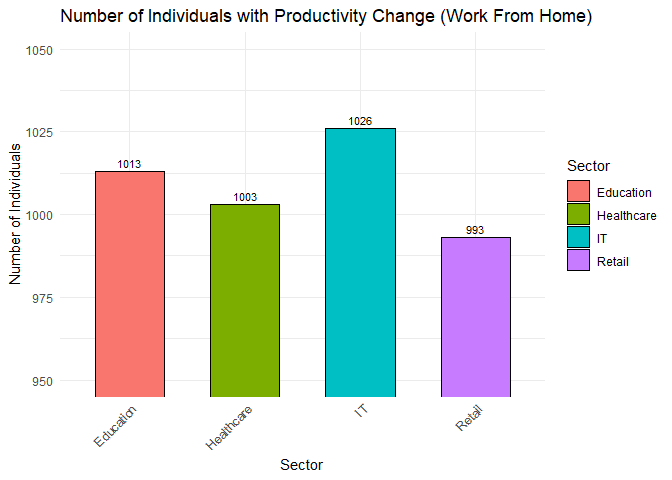

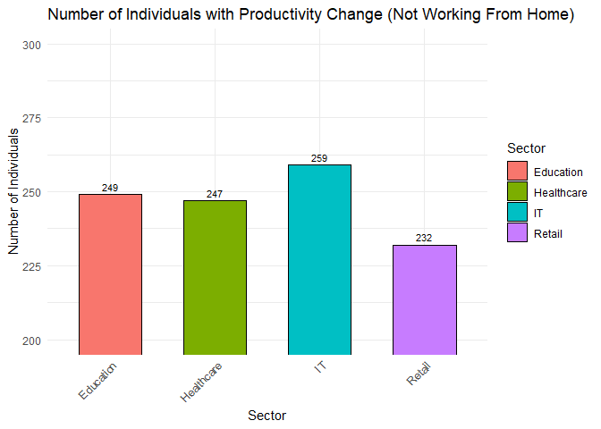

```r
# Segmentation analysis: Count of Productivity Change by Sector & Work From Home
if (all(c("Sector", "Work_From_Home", "Productivity_Change") %in% colnames(data))) {

  # Group data by Sector and Work_From_Home
  segmentation_analysis <- data %>%
    filter(Productivity_Change == 1) %>%  # Only include individuals with productivity change
    group_by(Sector, Work_From_Home) %>%
    summarise(
      Count = n(),  # Count the number of individuals with a change
      .groups = "drop"
    )

  print("Segmentation Analysis: Number of Individuals with Productivity Change by Sector and Work From Home")
  print(segmentation_analysis)

  # Split the data into two subsets: Work From Home (1) and Not Work From Home (0)
  work_from_home <- segmentation_analysis %>% filter(Work_From_Home == 1)
  not_work_from_home <- segmentation_analysis %>% filter(Work_From_Home == 0)

  # Plot: Number of Individuals (Work From Home) - Zoom in to 950-1050

  print("Segmentation Analysis: Number of Individuals with Productivity Change by Sector and Work From Home")
  print(segmentation_analysis)
# Split the data into two subsets: Work From Home (1) and Not Work From Home (0)
  work_from_home <- segmentation_analysis %>% filter(Work_From_Home == 1)
  not_work_from_home <- segmentation_analysis %>% filter(Work_From_Home == 0)

# Plot: Number of Individuals (Work From Home) - Zoom in to 950-1050

  plot_work_from_home <- ggplot(work_from_home, aes(x = Sector, y = Count, fill = Sector)) +
    geom_col(width = 0.6, color = "black") +
    geom_text(aes(label = Count), vjust = -0.5, size = 3) +
    coord_cartesian(ylim = c(950, 1050)) +  # Zoom in on y-axis for 950-1050
    labs(
      title = "Number of Individuals with Productivity Change (Work From Home)",
      x = "Sector",
      y = "Number of Individuals"
    ) +
    theme_minimal() +
    theme(axis.text.x = element_text(angle = 45, hjust = 1))



# Plot: Number of Individuals (Not Working From Home) - Zoom in to 200-300
  plot_not_work_from_home <- ggplot(not_work_from_home, aes(x = Sector, y = Count, fill = Sector)) +
    geom_col(width = 0.6, color = "black") +
    geom_text(aes(label = Count), vjust = -0.5, size = 3) +
    coord_cartesian(ylim = c(200, 300)) +  # Zoom in on y-axis for 200-300
    labs(
      title = "Number of Individuals with Productivity Change (Not Working From Home)",
      x = "Sector",
      y = "Number of Individuals"
    ) +
    theme_minimal() +
    theme(axis.text.x = element_text(angle = 45, hjust = 1))
  print(plot_work_from_home)
  print(plot_not_work_from_home)
}
```

```r
# The analysis shows that productivity trends vary by sector and work arrangement. In Education and IT, employees working on-site exhibit slightly higher productivity, likely due to the collaborative and interactive nature of tasks in these sectors. In contrast, Healthcare and Retail benefit more from remote work, with remote employees showing higher productivity. This is particularly evident in Retail, where remote work roles (e.g., e-commerce or customer service) outperform on-site roles, which may face challenges like reduced foot traffic or operational constraints. Median productivity remains consistent across most groups, except for on-site employees in Healthcare and Retail, where it drops to 0, highlighting potential struggles in these scenarios. These findings suggest that while remote work enhances productivity in some sectors, Education and IT may benefit from hybrid models to balance collaboration and flexibility. Retail operations could focus on supporting on-site employees to mitigate productivity challenges.
```

[output not shown]

[output not shown]

#### Question 3: What is the impact of working from home on productivity change? - Childcare Responsibilities & Working from Home

```
## [1] "Impact of Childcare Responsibilities on Productivity by Work From Home Status"
## # A tibble: 4 × 3
##   Work_From_Home Childcare_Responsibilities Count
##            <dbl>                      <dbl> <int>
## 1              0                          0   592
## 2              0                          1   395
## 3              1                          0  2440
## 4              1                          1  1595
```

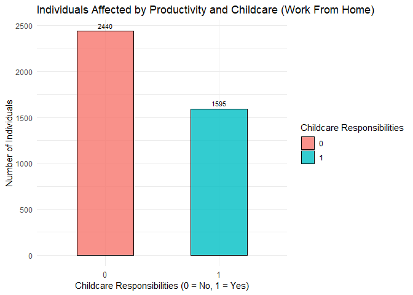

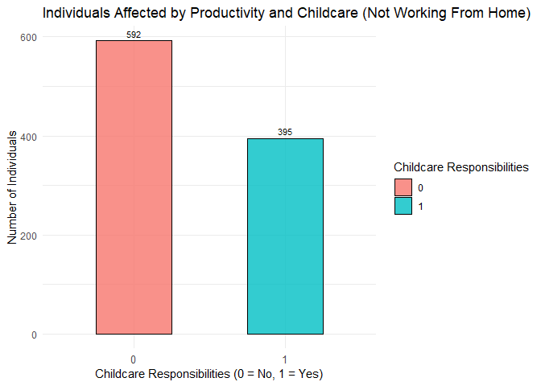

```r
if (all(c("Childcare_Responsibilities", "Work_From_Home", "Productivity_Change") %in% colnames(data))) {
  # Perform analysis: Group by Work_From_Home and Childcare_Responsibilities
  childcare_analysis <- data %>%
    filter(Productivity_Change == 1) %>%  # Filter only individuals affected by productivity change
    group_by(Work_From_Home, Childcare_Responsibilities) %>%
    summarise(
      Count = n(),  # Count the number of individuals
      .groups = "drop"
    )

  print("Impact of Childcare Responsibilities on Productivity by Work From Home Status")
  print(childcare_analysis)

  # Split data into two subsets: Work From Home (1) and Not Work From Home (0)
  work_from_home <- childcare_analysis %>% filter(Work_From_Home == 1)
  not_work_from_home <- childcare_analysis %>% filter(Work_From_Home == 0)

  # Plot: Work From Home
  plot_work_from_home <- ggplot(work_from_home, aes(x = as.factor(Childcare_Responsibilities), y = Count, fill = as.factor(Childcare_Responsibilities))) +
    geom_bar(stat = "identity", width = 0.5, color = "black", alpha = 0.8) +
    geom_text(aes(label = Count), vjust = -0.5, size = 3) +
    labs(
      title = "Individuals Affected by Productivity and Childcare (Work From Home)",
      x = "Childcare Responsibilities (0 = No, 1 = Yes)",
      y = "Number of Individuals",
      fill = "Childcare Responsibilities"
    ) +
    theme_minimal() +
    theme(axis.text.x = element_text(size = 10, angle = 0, hjust = 0.5))

  # Plot: Not Working From Home
  plot_not_work_from_home <- ggplot(not_work_from_home, aes(x = as.factor(Childcare_Responsibilities), y = Count, fill = as.factor(Childcare_Responsibilities))) +
    geom_bar(stat = "identity", width = 0.5, color = "black", alpha = 0.8) +
    geom_text(aes(label = Count), vjust = -0.5, size = 3) +
    labs(
      title = "Individuals Affected by Productivity and Childcare (Not Working From Home)",
      x = "Childcare Responsibilities (0 = No, 1 = Yes)",
      y = "Number of Individuals",
      fill = "Childcare Responsibilities"
    ) +
    theme_minimal() +
    theme(axis.text.x = element_text(size = 10, angle = 0, hjust = 0.5))

  # Display the plots
  print(plot_work_from_home)
  print(plot_not_work_from_home)
}
```

```r
#The analysis shows that employees without childcare responsibilities generally benefit slightly from remote work, with higher average productivity (0.503) compared to those working on-site (0.500). In contrast, employees with childcare responsibilities show slightly lower productivity when working from home (0.501) compared to those not working from home (0.504), likely due to competing demands at home. Median productivity remains consistent across groups, with those managing childcare responsibilities showing a median value of 1 regardless of work arrangement, suggesting that childcare responsibilities do not drastically impact productivity for most employees. Overall, remote work appears more beneficial for employees without childcare responsibilities, while those with childcare may need additional support to balance their responsibilities effectively.
```

#### Question 3: What is the impact of working from home on productivity change? - Health Issues & Working from Home

```
## [1] "Impact of Remote Work on Productivity for Employees with Health Issues:"
## # A tibble: 4 × 5
##   Health_Issue Work_From_Home Avg_Productivity_Change Median_Productivity_Change
##          <dbl>          <dbl>                   <dbl>                      <dbl>
## 1            0              0                   0.506                          1
## 2            0              1                   0.501                          1
## 3            1              0                   0.491                          0
## 4            1              1                   0.506                          1
## # ℹ 1 more variable: Count <int>
```

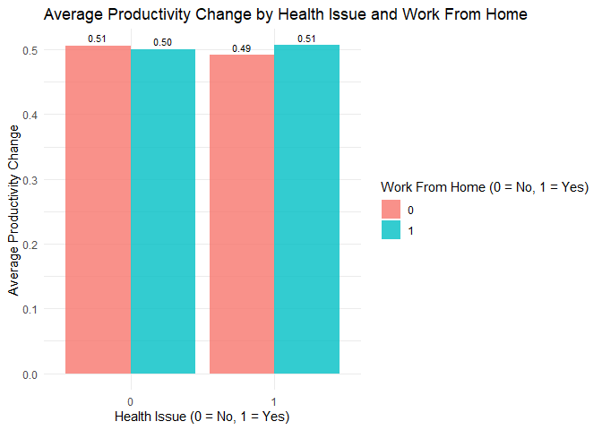

```r
# Analyze the impact of remote work on productivity for employees with Health Issues
if (all(c("Health_Issue", "Work_From_Home", "Productivity_Change") %in% colnames(data))) {

  # Ensure necessary columns are numeric
  if (!is.numeric(data$Productivity_Change)) {
    data$Productivity_Change <- as.numeric(data$Productivity_Change)
  }
  if (!is.numeric(data$Health_Issue)) {
    data$Health_Issue <- as.numeric(data$Health_Issue)
  }
  if (!is.numeric(data$Work_From_Home)) {
    data$Work_From_Home <- as.numeric(data$Work_From_Home)
  }

  # Filter valid data
  data_filtered <- data %>%
    filter(!is.na(Health_Issue) & !is.na(Work_From_Home) & !is.na(Productivity_Change))

  # Perform grouped analysis
  health_issue_analysis <- data_filtered %>%
    group_by(Health_Issue, Work_From_Home) %>%
    summarise(
      Avg_Productivity_Change = mean(Productivity_Change, na.rm = TRUE),
      Median_Productivity_Change = median(Productivity_Change, na.rm = TRUE),
      Count = n(),
      .groups = "drop"
    )

  # Print the summary table
  print("Impact of Remote Work on Productivity for Employees with Health Issues:")
  print(health_issue_analysis)

  # Visualize the data
  ggplot(health_issue_analysis, aes(x = as.factor(Health_Issue), y = Avg_Productivity_Change, fill = as.factor(Work_From_Home))) +
    geom_bar(stat = "identity", position = "dodge", alpha = 0.8) +
    geom_text(aes(label = sprintf("%.2f", Avg_Productivity_Change)),
              position = position_dodge(width = 0.9),
              vjust = -0.5,
              size = 3) +
    labs(
      title = "Average Productivity Change by Health Issue and Work From Home",
      x = "Health Issue (0 = No, 1 = Yes)",
      y = "Average Productivity Change",
      fill = "Work From Home (0 = No, 1 = Yes)"
    ) +
    theme_minimal() +
    theme(axis.text.x = element_text(angle = 0, hjust = 0.5))
}
```

```r
# The analysis reveals that remote work has varying impacts on productivity depending on whether employees have health issues. For employees without health issues, those working on-site show a slightly higher average productivity change (0.506) compared to remote workers (0.501), but the difference is minimal, and both groups maintain a median productivity change of 1. In contrast, for employees with health issues, remote work appears to mitigate productivity declines. On-site employees with health issues show a lower average productivity change (0.491) and a median productivity change of 0, whereas remote employees with health issues show an average productivity change of 0.506 and a median of 1. This indicates that remote work provides a more accommodating environment for employees with health issues, helping them achieve similar productivity levels to their counterparts without health issues. Overall, the results suggest that remote work may serve as an effective strategy to support productivity for employees with health-related challenges.
```

```
## [1] "Impact of Stress Level on Productivity by Work From Home "
## # A tibble: 6 × 5
##   Work_From_Home Stress_Level Avg_Productivity Median_Productivity Count
##            <dbl> <fct>                   <dbl>               <dbl> <int>
## 1              0 low                     0.51                    1   400
## 2              0 medium                  0.484                   0   965
## 3              0 high                    0.525                   1   602
## 4              1 low                     0.501                   1  1608
## 5              1 medium                  0.507                   1  3991
## 6              1 high                    0.495                   0  2434
```

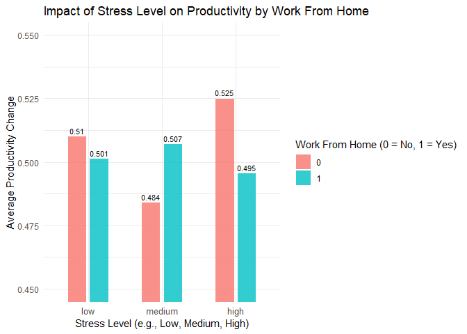

```r
if (all(c("Stress_Level", "Work_From_Home", "Productivity_Change") %in% colnames(data))) {
  stress_analysis <- data %>%
    group_by(Work_From_Home, Stress_Level) %>%
    summarise(
      Avg_Productivity = mean(Productivity_Change, na.rm = TRUE),
      Median_Productivity = median(Productivity_Change, na.rm = TRUE),
      Count = n(),
      .groups = "drop"
    )

  print("Impact of Stress Level on Productivity by Work From Home ")
  print(stress_analysis)
   # Create a graph to visualize the analysis
  ggplot(stress_analysis, aes(x = as.factor(Stress_Level), y = Avg_Productivity, fill = as.factor(Work_From_Home))) +
    geom_bar(stat = "identity", position = position_dodge(width = 0.6), width = 0.5, alpha = 0.8) +
    geom_text(aes(label = round(Avg_Productivity, 3)),
              position = position_dodge(width = 0.6),
              vjust = -0.5,
              size = 3) +
    labs(
      title = "Impact of Stress Level on Productivity by Work From Home ",
      x = "Stress Level (e.g., Low, Medium, High)",
      y = "Average Productivity Change",
      fill = "Work From Home (0 = No, 1 = Yes)"
    ) +
    coord_cartesian(ylim = c(0.45, 0.55)) +  # Adjust the visible range if needed
    theme_minimal() +
    theme(axis.text.x = element_text(size = 10, angle = 0, hjust = 0.5))
}
```

```r
#The analysis reveals that employees with medium stress levels benefit the most from remote work, showing a higher average productivity change (0.507) compared to those not working from home (0.484), likely due to the flexibility and work-life balance remote work provides. Conversely, employees with high stress levels experience slightly lower productivity when working remotely (0.495) compared to in-person work (0.525), suggesting they may require more immediate support or structure. For employees with low stress levels, productivity outcomes are relatively balanced between remote (0.501) and in-person work (0.51). Overall, while remote work appears advantageous for those with moderate stress, high-stress employees may benefit from targeted support to thrive in remote environments.
```

#### Question 5: Do employees who experienced salary cuts show different productivity trends compared to those with stable salaries?

```r
# Analyze the relationship between Salary Changes and Productivity Change
if (all(c("Salary_Changes", "Productivity_Change") %in% colnames(data))) {

  # Ensure necessary columns are numeric
  if (!is.numeric(data$Productivity_Change)) {
    data$Productivity_Change <- as.numeric(data$Productivity_Change)
  }
  if (!is.numeric(data$Salary_Changes)) {
    data$Salary_Changes <- as.numeric(data$Salary_Changes)
  }

  # Filter valid data
  data_filtered <- data %>%
    filter(!is.na(Salary_Changes) & !is.na(Productivity_Change))

  # Perform statistical summary
  salary_analysis <- data_filtered %>%
    group_by(Salary_Changes) %>%
    summarise(
      Avg_Productivity_Change = mean(Productivity_Change, na.rm = TRUE),
      Median_Productivity_Change = median(Productivity_Change, na.rm = TRUE),
      Count = n()
    )

  print("Analysis of Productivity Change by Salary Changes:")
  print(salary_analysis)

  # Perform a t-test to test if the means of the two groups are significantly different
  salary_cut_group <- data_filtered %>%
    filter(Salary_Changes == 1) %>%
    pull(Productivity_Change)

  stable_salary_group <- data_filtered %>%
    filter(Salary_Changes == 0) %>%
    pull(Productivity_Change)

  t_test_result <- t.test(salary_cut_group, stable_salary_group)

  print("T-test Results:")
  print(t_test_result)
# The analysis of productivity change based on salary changes shows minimal differences between employees who experienced salary cuts and those with stable salaries. The average productivity change for employees with stable salaries (0.502) is nearly identical to those with salary cuts (0.501). Both groups have a median productivity change of 1, suggesting that the central tendency of productivity is similar across the two groups. A Welch Two-Sample t-test was conducted to compare the means, resulting in a t-value of -0.1154 and a p-value of 0.9081. This high p-value indicates no statistically significant difference in productivity changes between the two groups. The 95% confidence interval (-0.0262, 0.0233) further confirms the lack of meaningful difference. Overall, salary changes appear to have negligible impact on productivity change.
}
```

```
## [1] "Analysis of Productivity Change by Salary Changes:"
## # A tibble: 2 × 4
##   Salary_Changes Avg_Productivity_Change Median_Productivity_Change Count
##            <dbl>                   <dbl>                      <dbl> <int>
## 1              0                   0.502                          1  8052
## 2              1                   0.501                          1  1948
## [1] "T-test Results:"
##
##  Welch Two Sample t-test
##
## data:  salary_cut_group and stable_salary_group
## t = -0.1154, df = 2960.7, p-value = 0.9081
## alternative hypothesis: true difference in means is not equal to 0
## 95 percent confidence interval:
##  -0.02621670  0.02330238
## sample estimates:
## mean of x mean of y
## 0.5010267 0.5024839
```